#### **To: Chris Lee and Management**

#### **From: Jordan Gropper**

#### **Date: 07/07/21**

#### **RE: Zillow Data**

After thurough analysis of the data, we have come up with a set of expected and unexpected results. As expected, a home with more living space tends to sell for more, this trend is also the case for the amount of bedrooms, floors and bathrooms. The most common homes in the market, that sell the most, tend to be 1 to 2 floors, and have 1-3 bathrooms. These homes tend to have a price that falls between $180 per square foot and $318 per square foot. Surprisingly, we found that current condition is not always the most important factor for price, and that recent homes are in less quality condition than some homes built before 2000, but the lowest condition homes are from before the 1990’s presumably, because they have had longer to deteriorate. The graph below shows current condition of the home, as well as when it was built, and the median price per sqft for that condition, from that year.

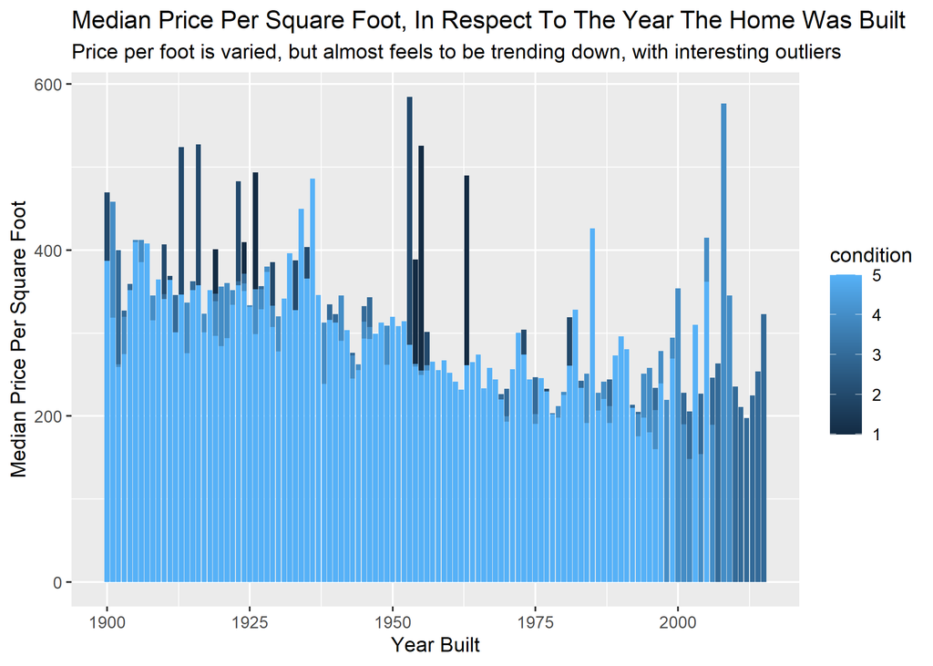

- I found it interesting how there are a lump of homes from around the 1950s that are in poor condition, but have such high median prices per squarefoot, costing more than other really high quality homes.

  -This could be a data entry error, but more likely than not is a outlier in the data itself.
  - I left it in to preserve the full story of the data.
  - As the table shows below, there are only 30 homes with the ranking of condition 1, which is the poorest.

| 1 | 2 | 3 | 4 | 5 |
| --- | --- | --- | --- | --- |
| 30 | 172 | 14031 | 5679 | 1701 |

| V1 | V2 | V3 | V4 | V5 |
| --- | --- | --- | --- | --- |
| 1.0000 | 2.0000 | 3.0000 | 4 | 5.0000 |
| 246.7949 | 210.5721 | 239.2694 | 250 | 284.6626 |

The amount of homes that have low condition, also tend to have a more expensive median cost per foot, with a median of $246.79. This is compared to the amount of really nice condition homes that are at $284.66. The Median of the second and third rank of condition are also lower than the lowest rank which is interesting.

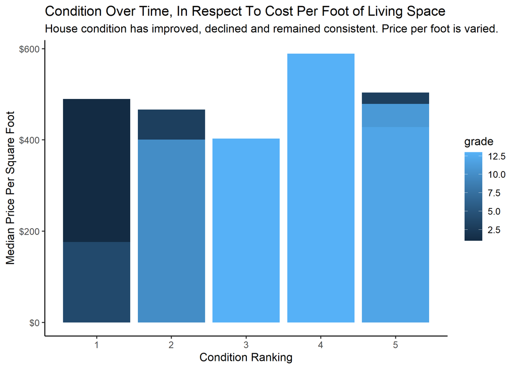

With occurnces where poor initial condition, and poor current condition can both be more expensive than mid range homes, there could be another variable at play. This could entirely be because there are a few of these observations that are really rare, but behave this way. It is also possible that it has to do with the particular neighbor hoods or zip code they are in, as shown below.

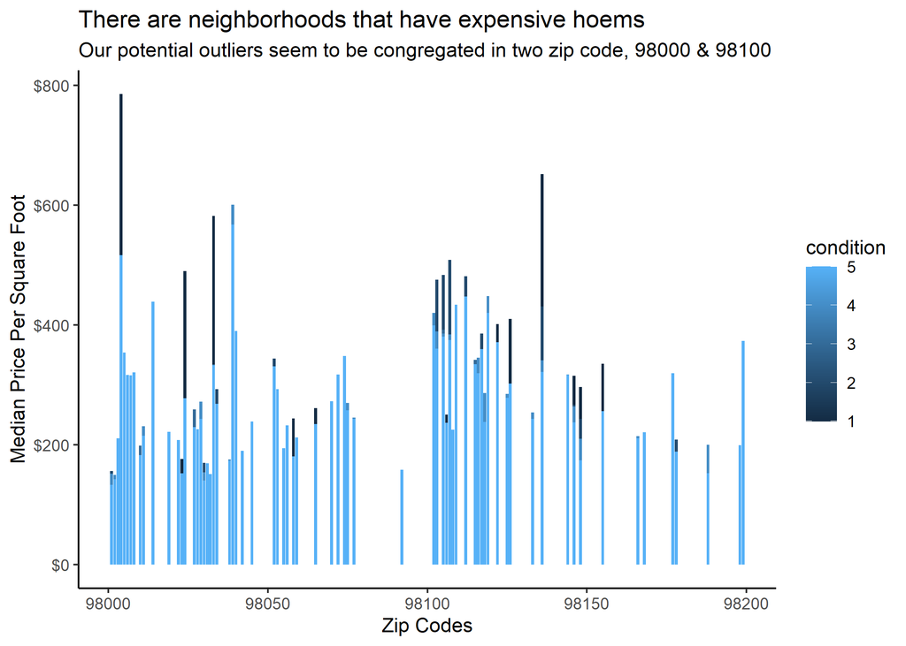

- As seen above there is also an odd concentration of home quality, and expensiv per capita living space in a few of the zip codes. Most notably 98000 and 98100. I imagine that land prices may be responsible for this, as the initial quality of the build is low.
  - Despite these occurences there are very few of them, so they may not be worth noting.
  - A look at regression shows a few interesting things as well.

[figure not shown]

```
##
## Call:
## lm(formula = living_sqft_price ~ grade + condition + floors +
##     bathrooms + bedrooms + zip_code + yr_built, data = houses)
##
## Residuals:
##     Min      1Q  Median      3Q     Max
## -294.16  -63.11  -12.69   47.70 1079.32
##
## Coefficients:
##               Estimate Std. Error t value Pr(>|t|)
## (Intercept) -7.823e+03  1.323e+03  -5.912 3.42e-09 ***
## grade        3.798e+01  7.612e-01  49.891  < 2e-16 ***
## condition    6.345e+00  1.092e+00   5.808 6.40e-09 ***
## floors       2.245e+01  1.513e+00  14.831  < 2e-16 ***
## bathrooms   -5.820e+00  1.347e+00  -4.320 1.57e-05 ***
## bedrooms    -3.261e+01  8.315e-01 -39.212  < 2e-16 ***
## zip_code     1.125e-01  1.326e-02   8.483  < 2e-16 ***
## yr_built    -1.609e+00  3.045e-02 -52.838  < 2e-16 ***
## ---
## Signif. codes:  0 '***' 0.001 '**' 0.01 '*' 0.05 '.' 0.1 ' ' 1
##
## Residual standard error: 95.46 on 21605 degrees of freedom
## Multiple R-squared:  0.2484, Adjusted R-squared:  0.2482
## F-statistic:  1020 on 7 and 21605 DF,  p-value: < 2.2e-16
```

I hope this helps portray the interesting trends in the housing market within the area of data collection. The trends of quality, and specific zip code location are particularly important. If more data was collected on some of the less observed variables, they could have a significant impact as well.

Best regards,

Quick Project 1 Team.